# Cotas para escola pública na USP e inclusão racial - Subsídios para discussão

Paulo Inácio Prado (Depto de Ecologia, IBUSP, prado@ib.usp.br)

26 de junho de 2017

# Contextualização

Este documento é resultado do debate sobre cotas raciais que ocorreu em minha unidade, no âmbito da greve estudantil de 2016. Sou imensamente grato aos estudantes e colegas do IB que nesse processo pautaram sua ação no diálogo, respeito à divergência de ideias e no debate fundamentado. Foi a atitude universitária dessas pessoas que me estimulou a contribuir com as análises aqui apresentadas.

A primeira versão do documento é de 22 de junho de 2016. Desde então fiz pequenas correções e atualizações dos dados. Embora algumas análises estejam restritas ao IB, a maioria é sobre os dados de toda a USP. Divulgo-as na expectativa que contribuam para um debate fundamentado sobre inclusão em nossa universidade. Um resumo das conclusões foi publicado em setembro de 2016 no Jornal da USP [^1].

Desde 2016 as unidades unidades da USP podem destinar até 30% de suas vagas de graduação para o SiSU – Sistema de Seleção Unificada do Ministério da Educação [^2]. Essas vagas podem ainda ser destinadas integral ou parcialmente a candidatos oriundos de escolas públicas e a candidatos que se autodeclaram *pretos, pardos ou indígenas* (PPI).

Uma das pautas da greve estudantil de 2016 foi a criação de cotas raciais no vestibular da USP. Embora ainda não haja uma política de inclusão racial da USP como um todo, as vagas do SISU criaram a oportunidade para as unidades promoverem alguma inclusão racial em seus cursos.

Em junho de 2016 os estudantes do Instituto de Biociências levaram o debate à Congregação, que aprovou que 30% das vagas para o vestibular de sua graduação em Ciências Biológicas seriam preenchidas pelo SISU. Todas as vagas foram destinadas exclusivamente a candidatos que cursaram o ensino médio em escolas públicas. Além disso, um terço dessas vagas foram destinadas exclusivamente a candidatos que se declararem PPI.

# As metas de inclusão da USP

Em 2013 a USP estabeleceu em seu Plano Institucional [^3] as seguintes metas para 2018:

> “I- 50% (cinquenta por cento) dos alunos matriculados em cada curso e em cada turno tendo cursado integralmente o ensino médio em escolas públicas;

> II – dentro desses 50% (cinquenta por cento) de matriculados oriundos de escolas públicas, o percentual de pretos, pardos e indígenas deverá atingir aquele verificado pelo último censo demográfico do IBGE."

O Programa de inclusão social da USP (INCLUSP) iniciou-se em 2007, concedendo bônus de 3% nas notas das duas fase dos vestibular para candidatos que cursaram todo ensino médio em escolas públicas. Nos anos seguintes os critérios foram diversificados e valores de bônus foram gradativamente aumentados [^4].

A partir do vestibular de 2014 foi incluído um bônus adicional de 5% aos candidatos de escolas públicas que se identificarem como “pretos, pardos ou indígenas” (PPI).

Neste documento usei os dados da pesquisa de perfil socioeconômico dos candidatos inscritos e matriculados pela FUVEST. A partir do ano de 2000 a pesquisa pergunta a raça/cor dos candidatos, com as opções “branca”, “preta”, “parda”, “amarela”, “indígena”. Os dados da FUVEST não incluem as inscrições e matrículas pelo Sistema de Seleção Unificada do MEC (SISU), usado pela USP desde 2016 para uma parcela das vagas.

# Progresso das metas

## Proporção de oriundos de escolas públicas

O gráfico abaixo mostra a proporção dos matriculados após a última chamada de cada vestibular que cursaram o ensino médio integralmente no ensino público (EP), segundo os dados da FUVEST. São mostrados dados até 2015, quando a única via de ingresso era a FUVEST [^5]. De 2000 a 2015 a proporção de EP na USP passou de 24% para 35%. O IB teve uma proporção abaixo da observada na USP, mas alcançou a média da universidade em 2014. Para cumprir a meta seria preciso aumentar a proporção de EP em  
15 pontos percentuais até 2018, sendo que foram necessários 15 anos para se avançar 11 pontos.

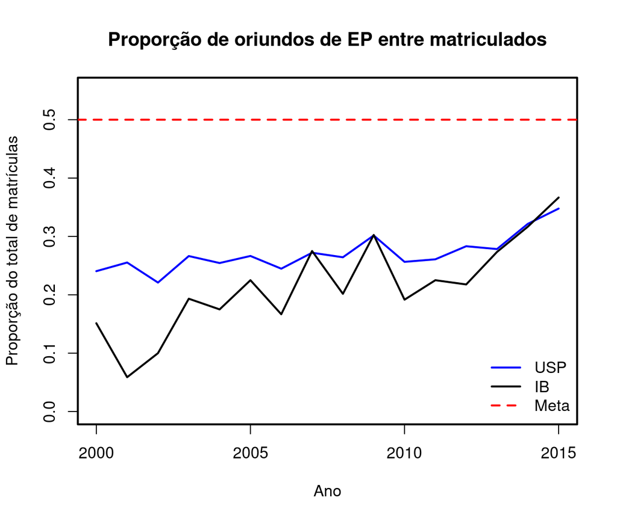

## Proporção de PPI entre oriundos de escola pública

Não foi possível obter a proporção de PPI entre os matriculados INCLUSP do IB do site da FUVEST. Para dar alguma referência, o gráfico mostra também a proporção de PPI no total de matriculados, na USP e no IB. Com a exceção de 2011, a proporção de PPI matriculados no IB esteve abaixo da observada na USP.

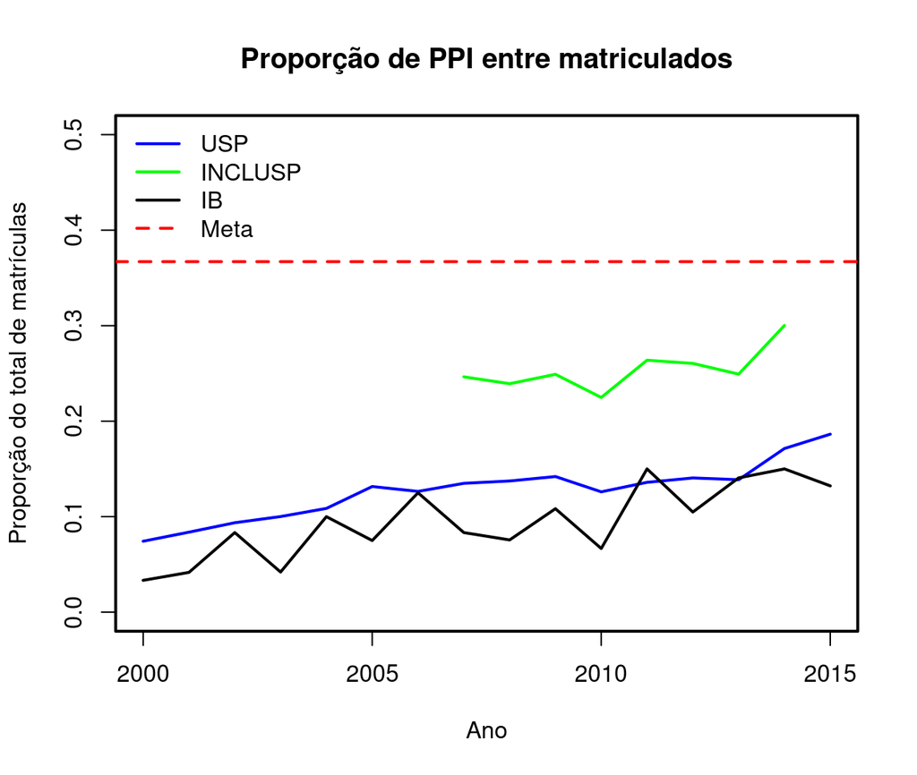

# Probabilidade de ingresso na USP

Os gráficos a seguir comparam a proporção de matriculados após a última chamada em relação ao número de inscritos na FUVEST, separados por origem escolar e raça. Os dados estão agregados em três períodos:

- Antes da criação do INCLUSP: 2000-2006
- Antes inclusão de bônus racial no INCLUSP: 2007-2013
- Após inclusão de bônus racial no INCLUSP: 2014-2016

## Probabilidade de ingresso de oriundos da escola particular e pública

O gráfico a seguir mostra a proporção matriculados/inscritos para candidatos que cursaram o ensino médio integralmente em escola pública ou não, em cada período. As barras são intervalos de confiança. Os traços pretos indicam a relação candidato/vaga dos vestibulares em cada período. Se houvesse igualdade de condições todas as proporções deveriam convergir para os valores da razão candidato/vaga.

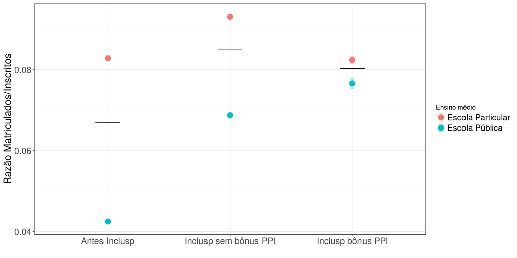

Antes da criação do INCLUSP, candidatos oriundos de escolas particulares tinham 1.9 vezes mais chance de ingressar na USP, comparados aos oriundos do ensino público. A desigualdade foi reduzida com o INCLUSP, especialmente após 2013, quando houve aumento nos valores dos bônus e inclusão de bônus racial. Ainda assim, a probabilidade de um candidato de escola particular ingressar continua maior ( 1.1 vezes em relação ao candidato do ensino público).

## Probabilidade de ingresso de candidatos PPI

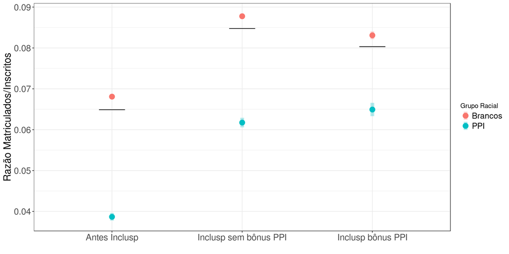

# INCLUSP e inclusão racial

## Probabilidade de ingresso de PPI pelo INCLUSP e fora dele

O gráfico a seguir mostra a proporção matriculados/ingressantes de candidatos PPI e brancos, dentro e fora do INCLUSP. A comparação foi feita entre os períodos em que programa não tinha bônus racial (2007-2013) e após a inclusão deste bônus (a partir de 2014).

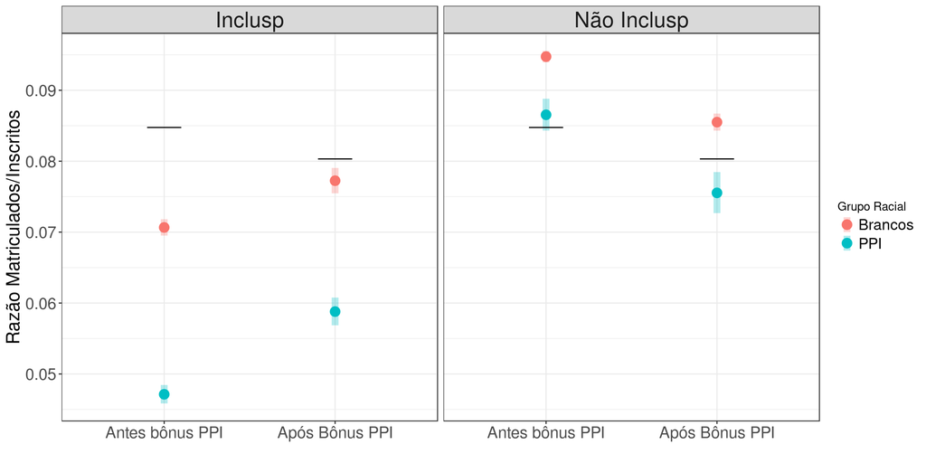

Mesmo com o bônus, os candidatos INCLUSP tiveram menor probabilidade de ingresso. Mais importante, a desigualdade racial é maior no grupo de candidatos que aderiram ao INCLUSP. Antes do bônus racial no INCLUSP, candidatos que se declararam brancos tiveram uma chance de aprovação 1.5 vezes maior que os que se declararam PPI. O bônus racial reduziu um pouco essa desigualdade (as chances dos brancos passaram a ser 1.3 vezes maiores no INCLUSP), mas os candidatos PPI oriundos de escola pública são ainda o grupo com menor probabilidade de ingresso.

Portanto, inclusão socioeconômica não é capaz de reduzir desigualdades raciais, porque essas desigualdades estão presentes em todos os estratos socioeconômicos. No caso em análise, o quadro é ainda pior, pois as desigualdades raciais se acentuam justo no estrato mais carente.

## Perfil econômico e racial de inscritos no INCLUSP

### Renda familiar

A análise acima pressupõe que os candidatos que se inscrevem no INCLUSP pertencem a estratos de menor renda. Para demonstrar essa premissa, o gráfico a seguir mostra a proporção dos candidatos do vestibular de 2015 em faixas de renda, nos dois grupos (optantes e não optantes pelo INCLUSP). O grupo de optantes pelo INCLUSP claramente tem menor renda familiar. Por exemplo, 74% dos candidatos que optaram pelo INCLUSP declararam renda familiar de até 5 salários mínimos. Entre os que não optaram o percentual é de 33%.

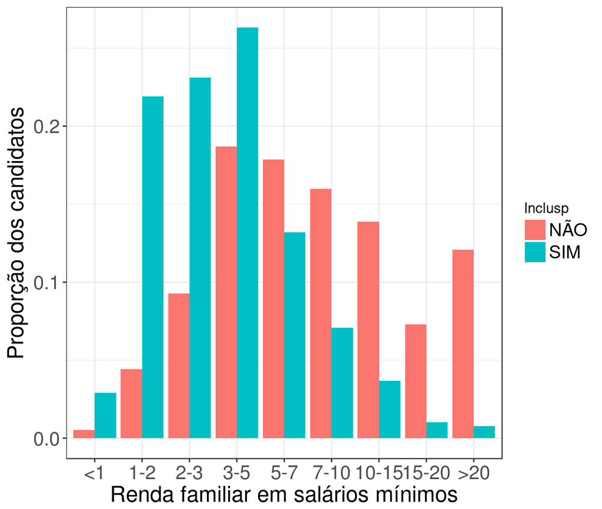

### Cor declarada

O grupo de inscritos que optaram pelo INCLUSP também difere marcadamente do grupos dos que não optaram pelo INCLUSP em termos raciais. O gráfico a seguir mostra, à esquerda, a proporção de inscritos no vestibular que se declararam PPI nesses dois grupos. Não houve muita variação entre os anos, e em todo o período 35% dos inscritos INCLUSP se declararam PPI. Entre os inscritos que não estavam no INCLUSP 11% se declararam PPI no período.

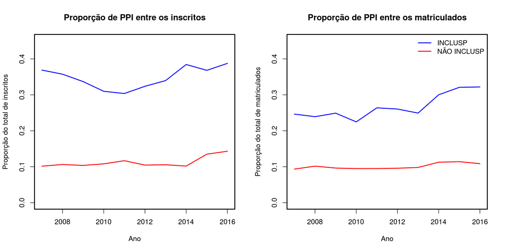

# Fonte de dados

Os dados foram obtidos do site da FUVEST (http://www.fuvest.br/, seção “Estatísticas” > “Questionário de Avaliação Sócio-Econômica”), usando os agrupamentos “Total carreiras USP” e “Candidatos que optaram pelo Inclusp”. Compilei também, dados dos anuários da USP, embora não tenha usado nessas análises (ver notas, abaixo).

As planilhas, códigos R e fonte deste documento estão no repositório público https://github.com/piLaboratory/inclusp . Críticas e sugestões podem ser enviadas como [pull requests](https://github.com/piLaboratory/inclusp/pulls), issues ou para prado@ib.usp.br.

## Lista das planilhas compiladas

### USP

- Número de inscritos, convocados e matriculados, por origem escolar (escola pública, particular, etc). Dados do anuário da USP, 1987-2015 : ensino_medio.csv
- Número de inscritos e matriculados, por origem escolar (escola pública, particular, etc). Dados do anuário da FUVEST, 2000-2016 : ensino_medio_fuvest.csv
- Número de inscritos e matriculados, por adesão ao INCLUSP e cor autodeclarada. Dados da FUVEST, 2007-2016 : inclusp.csv
- Número de inscritos e matriculados por adesão ao INCLUSP e faixas de renda familiar. Dados FUVEST, 2015-2016: inclusp_renda.csv
- Número de inscritos, convocados e matriculados, por cor autodeclarada, dados do anuário da USP e da Fuvest, 2000 - 20016: cor.csv